# Appendix, Michał Szumielewicz

# Setup

|  | total_day_minutes | total_day_charge | total_eve_minutes | total_eve_charge | total_night_minutes | total_night_charge | total_intl_minutes | total_intl_charge |
| --- | --- | --- | --- | --- | --- | --- | --- | --- |
| 0 | 265.1 | 45.07 | 197.4 | 16.78 | 244.7 | 11.01 | 10.0 | 2.70 |
| 1 | 161.6 | 27.47 | 195.5 | 16.62 | 254.4 | 11.45 | 13.7 | 3.70 |
| 2 | 243.4 | 41.38 | 121.2 | 10.30 | 162.6 | 7.32 | 12.2 | 3.29 |
| 3 | 299.4 | 50.90 | 61.9 | 5.26 | 196.9 | 8.86 | 6.6 | 1.78 |
| 4 | 166.7 | 28.34 | 148.3 | 12.61 | 186.9 | 8.41 | 10.1 | 2.73 |
| ... | ... | ... | ... | ... | ... | ... | ... | ... |
| 4995 | 235.7 | 40.07 | 223.0 | 18.96 | 297.5 | 13.39 | 9.9 | 2.67 |
| 4996 | 184.2 | 31.31 | 256.8 | 21.83 | 213.6 | 9.61 | 14.7 | 3.97 |
| 4997 | 140.6 | 23.90 | 172.8 | 14.69 | 212.4 | 9.56 | 13.6 | 3.67 |
| 4998 | 188.8 | 32.10 | 171.7 | 14.59 | 224.4 | 10.10 | 8.5 | 2.30 |
| 4999 | 129.4 | 22.00 | 267.1 | 22.70 | 154.8 | 6.97 | 9.3 | 2.51 |

5000 rows × 8 columns

I use the churn dataset with 5000 rows of 8 features and a target class.

# Train a tree-based ensemble model on the selected dataset; it can be one of random forest, GBM, CatBoost, XGBoost, LightGBM (various types) etc.

I choose an sklearn GB Classifier model

# Select two observations from the dataset and calculate the model's prediction.

|  | total_day_minutes | total_day_charge | total_eve_minutes | total_eve_charge | total_night_minutes | total_night_charge | total_intl_minutes | total_intl_charge |
| --- | --- | --- | --- | --- | --- | --- | --- | --- |
| 0 | 265.1 | 45.07 | 197.4 | 16.78 | 244.7 | 11.01 | 10.0 | 2.7 |

```
array([0])
```

|  | total_day_minutes | total_day_charge | total_eve_minutes | total_eve_charge | total_night_minutes | total_night_charge | total_intl_minutes | total_intl_charge |
| --- | --- | --- | --- | --- | --- | --- | --- | --- |
| 1 | 161.6 | 27.47 | 195.5 | 16.62 | 254.4 | 11.45 | 13.7 | 3.7 |

```
array([0])
```

# Next, for the same observations, calculate the decomposition of predictions, so-called variable attributions, using SHAP from two packages of choice, e.g. for Python: dalex and shap, for R: DALEX and iml.

[output not shown]

```
X does not have valid feature names, but GradientBoostingClassifier was fitted with feature names
```

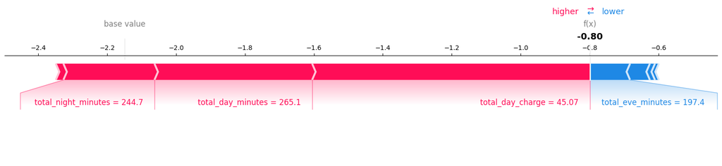

[output not shown]

```
X does not have valid feature names, but GradientBoostingClassifier was fitted with feature names
```

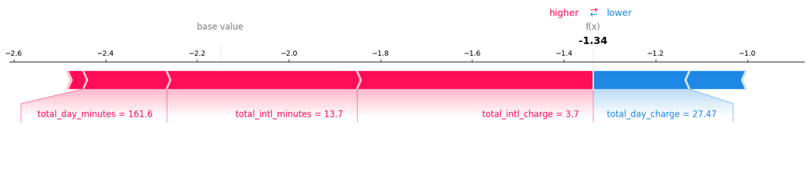

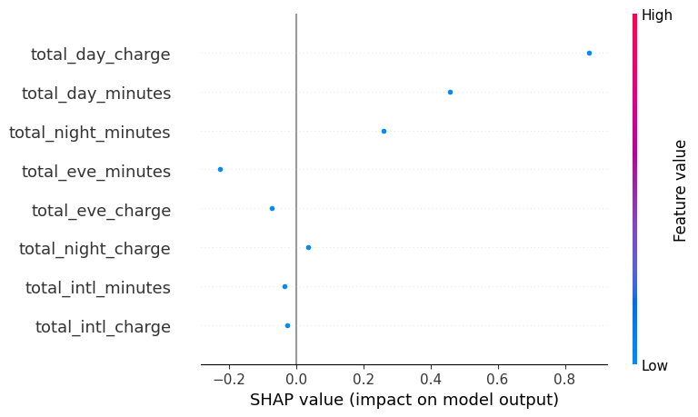

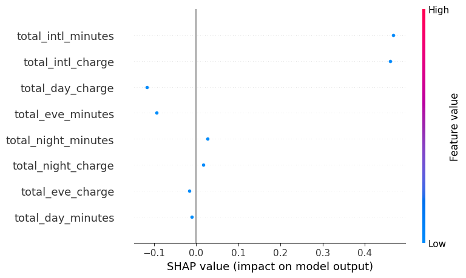

```
[[ 0.45747482  0.80642652 -0.11599582 -0.0147519   0.26422619  0.02184712
  -0.05743616 -0.01117459]]
[[ 0.45803883  0.87140022 -0.22737987 -0.07119635  0.26042984  0.03670278
  -0.03427483 -0.02498513]]
```

For the first observation the sets of Shapley values are very similar in except the highest one and the strongest negative one

```
[[ 0.18179071 -0.2107673  -0.12333963 -0.00044328  0.03373094  0.00157387
   0.41534549  0.51461772]]
[[-0.01055395 -0.11783336 -0.09487466 -0.01706964  0.02691806  0.01719033
   0.46687852  0.45997254]]
```

Again there are similar differences in the biggest Shapley values but this time the less important ones also differ by even bigger values

# Find any two observations in the dataset, such that they have different variables of the highest importance, e.g. age and gender have the highest (absolute) attribution for observation A, but race and class are more important for observation B.

Observations 6 and 44:

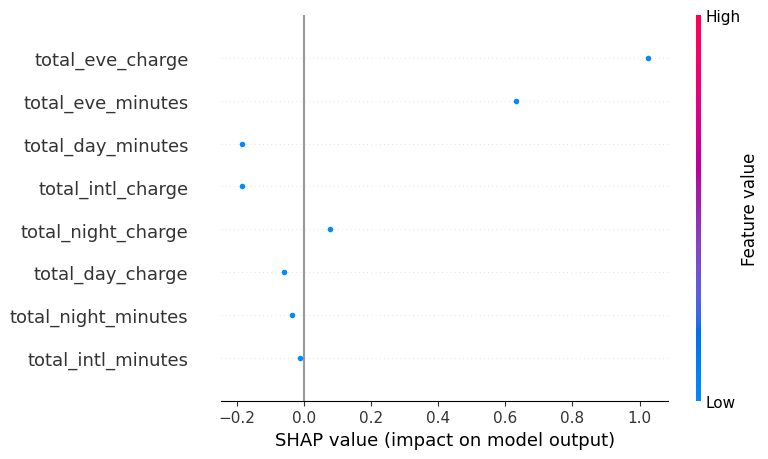

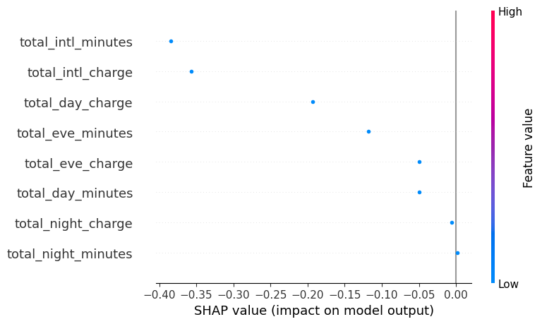

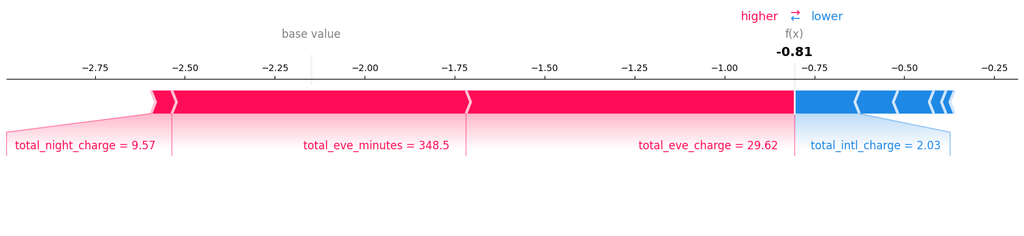

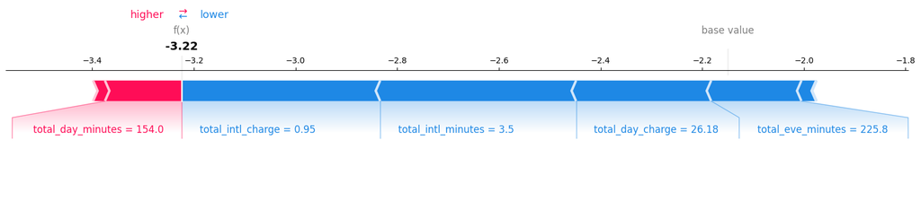

There does not seem to be much difference here between the results calculated by dalex and shap modules. There will be slight differences in shapley values but the general trends remained the same.

# Select one variable X and find two observations in the dataset such that for one observation, X has a positive attribution, and for the other observation, X has a negative attribution.

Variable: total_eve_minutes

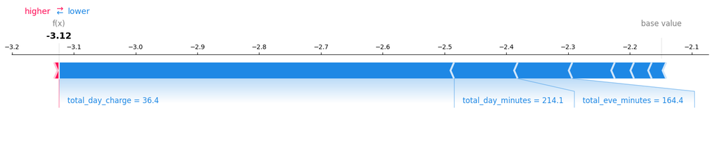

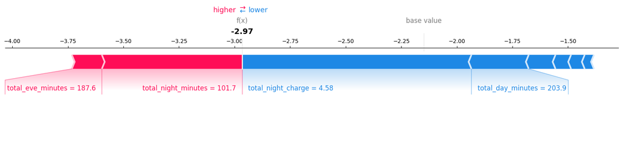

Total eve minutes here has opposite attributions and it is important enough to be displayed here for both observations.

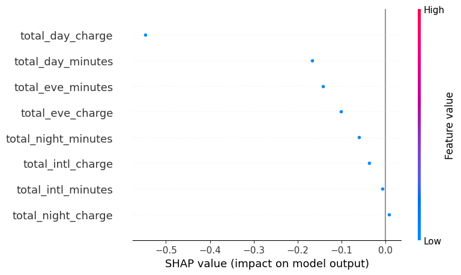

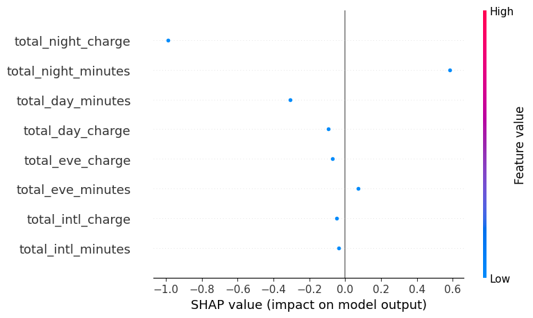

The shap package result is similar, it shows however that the impact of the variable for the second observation is not that important, especially with an observation heavily skewed towards one class (0).

# Train another model of any class: neural network, linear model, decision tree etc. and find an observation for which SHAP attributions are different between this model and the one trained in point (1).

I take a random forest classifier

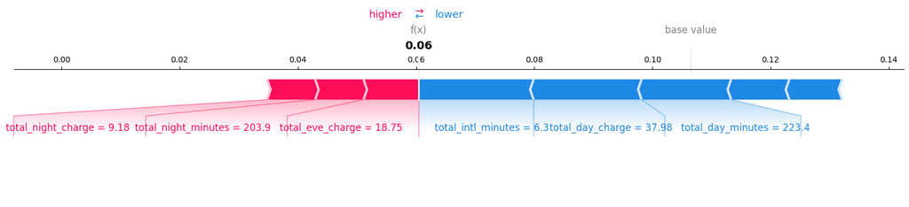

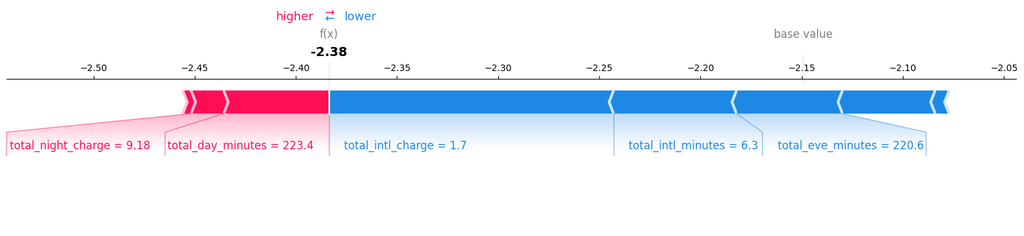

Explanations are vastly different for the different models, even with the same observation. The most important attribution for the GB classifier is not even the third most important for the trained random forest. total_day_minutes is somewhat important for both explanations but for one it has negative attribution and for the other positive. It looks like only the shapley values for total_intl_minutes are similar.

# Task B

v() = 0 v(A) = 20 v(B) = 20 v(C) = 60 v(A,B) = 60 v(A,C) = 70 v(B,C) = 70 v(A,B,C) = 100

Differences:

v(A) - v() = 20 v(A,B) - v(B) = 40 v(A,C) - v(C) = 10 v(A,B,C) - v(B,C) = 30

Shapley value for A equals (20 * 2 + 40 + 10 + 30 * 2)/6 = 25